# College major salary outcome and their unemployment rate analysis!

## We want to plot the indidual major's unemployment rates and we have achieved this with a horizontal barplot

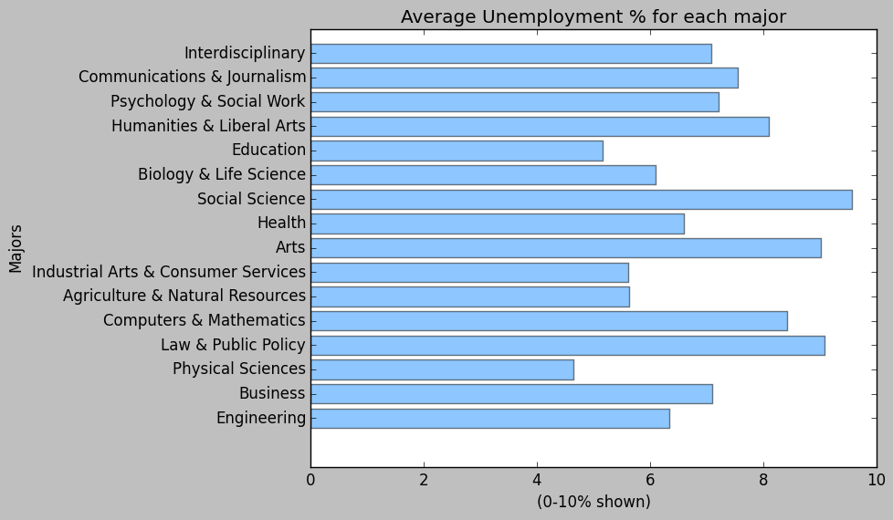

```python
import matplotlib.pyplot as plt; plt.rcdefaults()
import numpy as np
import matplotlib.pyplot as plt

# Import data file from URL into pd datafram in session
salary_data_url = 'https://raw.githubusercontent.com/fivethirtyeight/data/master/college-majors/recent-grads.csv'
data_file = urllib2.urlopen(salary_data_url)
df_bar = pd.read_csv(data_file, sep=',')

output_category_unemp=[]                # a list to store all the categories
for xcategory in df_bar['Major_category']:
    if xcategory not in output_category_unemp:
        output_category_unemp.append(xcategory)

category_unemployed = []
category_men = []
category_wom = []
small_fig_bubble = plt.figure()
for category in output_category_unemp:       #a for loop to set the values of those 16 majors by taking the mean salaries,totals etc.
    category_men.append((np.mean(df_bar[df_bar['Major_category'] == category].Men)))
    category_wom.append((np.mean(df_bar[df_bar['Major_category'] == category].Women)))
    category_unemployed.append((np.mean(100*(df_bar[df_bar['Major_category'] == category].Unemployment_rate))))

objects = ('Engineering', 'Business', 'Physical Sciences', 'Law & Public Policy', 'Computers & Mathematics', 'Agriculture & Natural Resources', 'Industrial Arts & Consumer Services', 'Arts', 'Health', 'Social Science', 'Biology & Life Science', 'Education', 'Humanities & Liberal Arts', 'Psychology & Social Work', 'Communications & Journalism', 'Interdisciplinary')
y_pos = np.arange(len(objects))   # we set the y axis lables
performance = category_unemployed


plt.barh(y_pos, performance, align='center',color='dodgerblue', alpha=0.5)
plt.yticks(y_pos, objects)
plt.xlabel('(0-10% shown)')
plt.ylabel('Majors')
plt.title('Average Unemployment % for each major')
plt.rcdefaults()
plt.show()
```

# This bar plot shows us the comparitive numbers between Men & Women

### We use horizontal bar plot to do so!

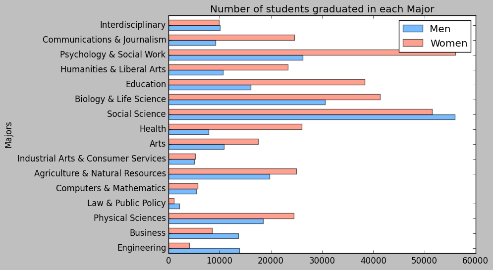

```python
# data to plot
n_groups = 16
tuple(category_men)
tuple(category_wom)

# create plot
fig, ax = plt.subplots()
index = np.arange(n_groups)
bar_width = 0.35
opacity = 0.6

rects1 = plt.barh(index, tuple(category_men), bar_width,
                 alpha=opacity,
                 color='dodgerblue',
                 label='Men')

rects2 = plt.barh(index + bar_width, tuple(category_wom), bar_width,
                 alpha=opacity,
                 color='tomato',
                 label='Women')


plt.ylabel('Majors')
plt.title('Number of students graduated in each Major')
plt.yticks(index + bar_width, (objects))
plt.legend()
plt.show()
```

### histogram of frequency of the median salary

A simple histogram thought but gives us a picture of the frequency of the median salary, again the value lies betweem 40k to 60k.

We tried to change the bin size above and below to this bins=50, and we are almost getting similar results!

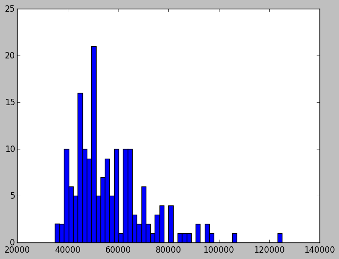

```python
salary = df['Median']
plt.hist(salary,bins=50)
```

### cumulative histogram

Now we create a cumulative histogram of the salary data and we can clearly see the maximum change is seen between 40K to 80K.

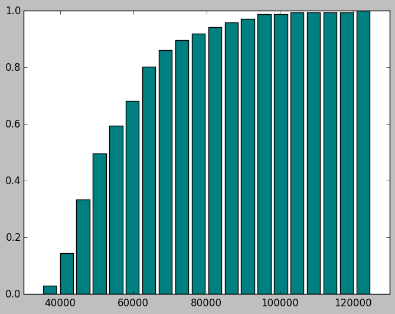

```python
n, bins, patches = plt.hist(salary, bins=20, normed=True, histtype='bar', rwidth=0.8, color=['teal'], cumulative=True)
#
# now we create a cumulative histogram of the salary data and we can clearly see the maximum change is seen between 40K to 80K.
#
plt.figure()
```

## Box plot and Violin plots: Our major findings are

#### From the Box plot below we will be able to find the major with the highest median salary and we can also see the order of the majors.

#### Below that from the violin plot we are able to notice the spread of the majors and the maximum majors have a salary range from 62,000 to 82,000

#### And from the other violin plot we see that the maximum number of majors have a unemployment rate spread between the 2% and 7%.

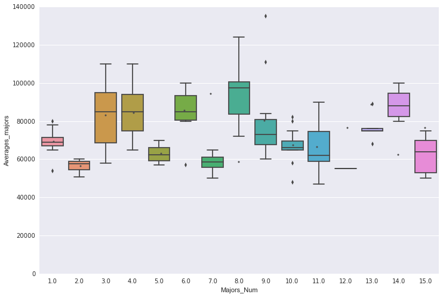

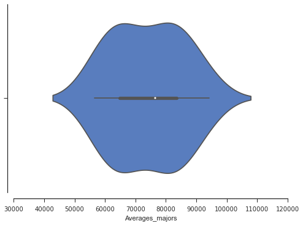

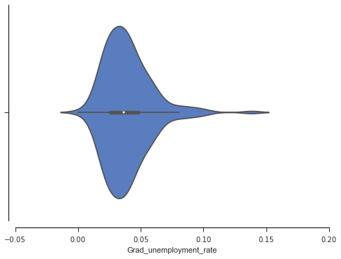

```python
%matplotlib inline
import matplotlib.pyplot as plt
np.random.seed(sum(map(ord, "categorical")))
from bokeh.plotting import figure, show
from bokeh.io import output_notebook
import csv
import seaborn as sns

grad_df = []
grad_df = pd.read_csv('Data.csv', delimiter=',')
grad_df1 = pd.read_csv('Data1.csv', delimiter=',')


x = grad_df['Majors_Num']
y = grad_df['Averages_majors']

ax = sns.boxplot(x=grad_df['Major_category'], y=grad_df['Grad_median'])
ax.figure.set_size_inches(12, 8)
sns.plt.ylim(0,)

sns.set(style="ticks", palette="muted", color_codes=True)
sns.stripplot(x = x , y = y,jitter=True, size=3, color=".3", linewidth=0)


f, ax = plt.subplots()
sns.violinplot(y)
sns.despine(offset=10, trim=False);
z = []

z = grad_df1['Grad_unemployment_rate']

z1 = grad_df1['Grad_P25']
z2 = grad_df1['Grad_P75']
z3 = grad_df1['Grad_employed']

f, ax = plt.subplots()
sns.violinplot(z)
sns.despine(offset=10, trim=False);
```

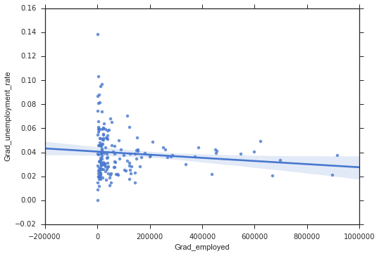

```python
sns.regplot(x=z3, y=z, data=grad_df1);    # a regression- reg plot that possibly plot the values of average unemployment rates.
```

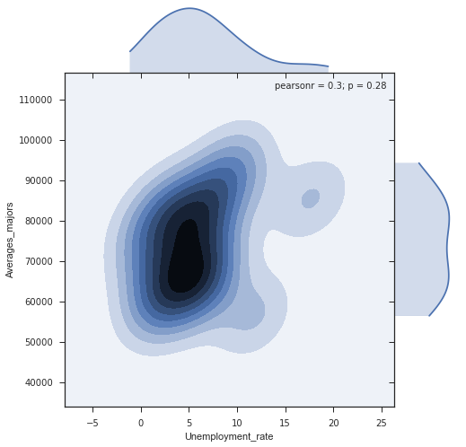

```python
import numpy as np, pandas as pd; np.random.seed(0)
import seaborn as sns
axisx=100*unemp_df['Unemployment_rate']
sns.set(style="ticks", color_codes=True) # a joint plot we are woking on to get a better view of unemployment rates.
sns.jointplot(x=axisx, y=y, kind="kde",size=7, space=0);
```

### Research questions and working hypotheses:

We came across various visualization in bits and pieces related to job trends but not all showed a comprehensive picture for students from all the majors. Since this is an intriguing subject for our self being a part of the data science masters degree program, we hope this is a vital analysis for any degree student. Also we would like to show a year on year trends, time series trends for a decade but currently this data only contain information for the 2010-2012, as a challenge we would like to come up with a newer data set and compare probably. Plus this proposal defines a basic outline of what we have conceived as of now and we are excited to work on and add few more interesting visualizations by effectively making use of the class learning and incorporation the design principals all across the mid-term project.

### Insights: insights that you got from the visualizations:

For most of the majors, employment rates is hovering around the 4% mark.

The majors with the highest salaries belong to the Engineering category.

ELECTRICAL, MECHANICAL, AND PRECISION TECHNOLOGIES AND PRODUCTION FILM VIDEO AND PHOTOGRAPHIC ARTS ENGINEERING AND INDUSTRIAL MANAGEMENT

The mentioned above 3 majors have the highest graduate unemployment rates.

But if I put a minimum number of students criteria:

If I took the minimum number of students as 100,000.

Then Fine Arts and Architecture had the highest unemployment rate.

If the minimum number of students I took as 50,000

Then Drama & Theatre Arts and Human Resources & Personnel Management had the highest unemployment rate.

### Future work:

Do a regression on the unemployment data. Collect the following years data. Compare the results.

We could also we which majors have a percentage increase in the salaries and which decrease.